# Rapport Projet

# I. Introduction

Depuis son lancement en 1996, Pokémon est devenu un phénomène mondial incontournable. Créé par Nintendo, Game Freak et Creatures, cet univers captivant s’est décliné sous de nombreuses formes : jeux vidéo, cartes à collectionner, séries animées, films, et bien plus encore. Avec plus de 1000 créatures différentes et des millions de fans à travers le monde, Pokémon est riche d’une immense quantité de données, allant des statistiques de combat aux types élémentaires, en passant par l’évolution des jeux et la popularité des cartes.

Dans le cadre de notre projet en IF36, nous avons choisi d’explorer cet univers sous un angle analytique à travers des visualisations de données interactives et informatives. Notre travail s’articule autour de plusieurs axes :

- Les jeux Pokémon : analyse des ventes, popularité, etc…
- Les cartes à collectionner : aperçu de leur rareté, valeur, etc…
- Les tournois de cartes Pokémon : prix des decks, pays les plus forts, etc…
- Les statistiques des Pokémon : étude comparative des forces et faiblesses des différentes créatures
- Les types de Pokémon : visualisation des répartitions, combinaisons les plus courantes et rapports de forces entre types

Ce projet a pour objectif de rendre accessible et ludique un ensemble de données complexes tout en mettant en lumière les aspects les plus emblématiques de l’univers Pokémon.

## Sources de données

Pour produire l’ensemble des visualisations présentes dans ce document, nous avons utilisé les jeux de données suivants :

### 1. The complete pokemon dataset ([dispo. ici](https://www.kaggle.com/datasets/mihirbindal/the-complete-pokemon-dataset))

Ce dataset sera notre jeu de données principal. En effet, ce jeu de données contient les **noms**, **le numéro du Pokédex**, leur **génération**, leurs **capacités**, des statistiques physiques comme la **taille** et le **poids**, leur **type**, leur **multiplicateur de défense contre chaque type**, etc. Ces données incluent non seulement les 890 Pokémon, mais aussi **leurs méga-évolutions**, leurs **formes de Galar**, **d’Alola** ainsi que leurs **formes alternatives**. Les données proviennent de deux sites communautaires : [pokemondb](https://pokemondb.net/) et [buldapedia](https://bulbapedia.bulbagarden.net/wiki/Main_Page)

### 2. Pokemon TCG All Cards 1999 - 2023 ([dispo. ici](https://www.kaggle.com/datasets/adampq/pokemon-tcg-all-cards-1999-2023?select=pokemon-tcg-data-master+1999-2023.csv))

Ce dataset est un jeu de données agrégé compilant des informations complètes sur les sets et cartes du jeu de cartes à collectionner Pokémon (TCG) de 1999 à 2023, provenant de l’API Pokémon TCG. Ce jeu de données offre une vue d’ensemble détaillée des cartes Pokémon TCG, incluant leurs attributs, capacités, attaques et autres informations pertinentes. Il constitue une ressource précieuse relier chaque pokémon et ses statistiques dans le jeu vidéo, à ses équivalents dans le jeu de carte physique.

### 3. Pokémon Trading Cards ([dispo. ici](https://www.kaggle.com/datasets/jacklacey/pokemon-trading-cards))

Ce dataset pourra être utilisé en complément du précédent. Il permet de relier les cartes du jeu à leur prix de vente. Il contient des données détaillant les cartes Pokémon en vente sur chaoscards.co.uk en 2022.

### 4. Limitless PTCGP All Data ([dispo. ici](https://www.kaggle.com/datasets/updatethisplz/limitless-ptcgp-all-data))

Ce dataset est similaire au numéro 2, mais se porte sur les cartes virtuelles (du jeu mobile sorti en 2024). Ainsi, il contient des informations sur les cartes des pokémons du jeu TCG Pocket. Il est mis à jour très régulièrement.

### 5. Sondage de popularité ([dispo. ici](https://pastebin.com/LvhaTx7w))

Ce dataset est le seul que nous avons trouvé pour obtenir des informations sur la popularité des pokémons. Il provient d’un sondage fait sur un forum de fans de la license (**52 725** votants). Réalisé en 2019, il ne contient donc pas la dernière génération de Pokémons. Les données sont également disponibles [ici](https://docs.google.com/spreadsheets/d/1c16Wh4AawHGbTi3Eq1DGZQdM4FMUlJO1YwXJZ_ylRvg/edit?gid=557303698#gid=557303698), où elles sont un peu analysées

### 6. Pokemon TCG - All Tournaments Decks (2011-2023) ([dispo. ici](https://www.kaggle.com/datasets/enriccogemha/pokemon-tcg-all-tournaments-decks-2011-2023))

Ce dataset contient lui aussi des données sur les cartes physiques, mais se concentre sur leur utilisation en tounoi. Ainsi, on peut savoir quelles cartes sont les plus jouées, et dans quels combos (= combinées avec quelles autres cartes) celles-ci sont jouées.

### 7. Pokemon Image Dataset ([dispo. ici](https://www.kaggle.com/datasets/vishalsubbiah/pokemon-images-and-types))

Ce dataset contient des photos de pokémon. Il contient l’ensemble des Pokémons jusqu’à la dernière version, mis à part certaines formes spéciales (formes de Galar par exemple)

### 8. Video Game Sales ([dispo. ici](https://www.kaggle.com/datasets/gregorut/videogamesales))

Ce dataset contient une liste des jeux vidéos vendus à plus de 100 000 copies (entre 1996 et 2014). Il peut nous permettre de lier les ventes des jeux vidéos pokémons, à par exemple, la popularité de certains pokémons.

# II. Exploration

## Etude des types

### 1.1. Visualisation des différents combos de types de Pokémon

*Objectif du graphique :*  
Ici, nous allons répondre à la question suivante : **Quel est le nombre de Pokémon par combinaison de types ?** En effet, les pokémons possèdent un type principal (type1) et un type secondaire (type2). Le but est de voir ici, si ces types sont équitablements répartis, où si on peut observer des tendances. Nous allons donc créer une heatmap permettant de visualiser les combinaisons de types de Pokémon.

*Présentation :*  
Pour réaliser ce graphique, nous avons utilisé les données du dataset “Pokemon_data”. Nous avons filtré les Pokémon qui n’ont pas de type secondaire (type2 = “None”). Nous avons ensuite compté le nombre de Pokémon par combinaison de types, puis nous avons ajouté des totaux pour chaque type principal et secondaire.

*Visualisation :*

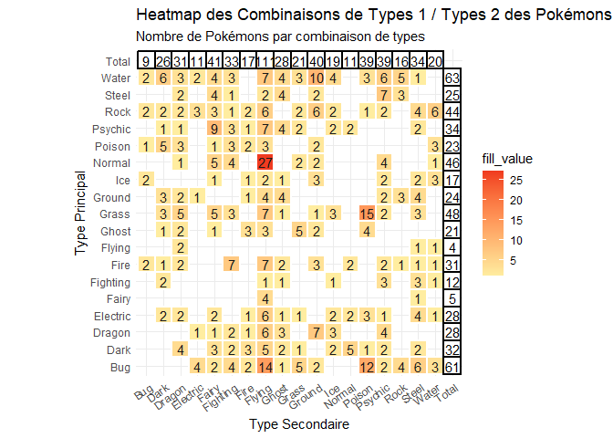

### 1.2. Efficacité d’un type de Pokémon face à un autre type de Pokémon

*Objectif du graphique :*  
Ici, nous allons répondre à la question suivante : **Face à quel type adverse chaque type d’attaque est-il meilleur ?** En effet, chaque pokémon possède un coefficient de dégats subits pour chaque type adverse. Par exemple, si un pokémon a un coéfficent de 2 pour le type Feu, il recevra 2 fois plus de dégats par attaque de type Feu. Le but est de voir ici, si ces coefficients sont équitablement répartis, où si on peut observer des tendances en fonction du type principal du pokémon.

*Présentation :*  
Pour réaliser ce graphique, nous avons utilisé les données du dataset “Pokemon_data”. Nous avons conservé les colonnes “name”, “type1” et les coefficients de dégats subits pour chaque type adverse. Nous avons ensuite calculé la moyenne des coefficients de dégats subits pour chaque type adverse, puis nous avons créé une heatmap pour visualiser ces moyennes.

*Visualisation :*

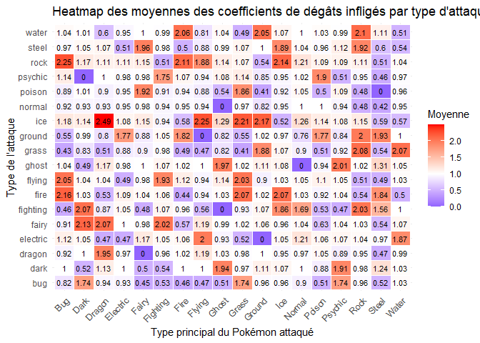

*Shiny Dashboard :* Ces visualisations sont également disponibles dans un **Shiny Dashboard** interactif, permettant d’explorer les données de manière plus dynamique en filtrant les générations à inclure.

### 1.3. Popularité des types de Pokémons

*Objectif du graphique :*  
Ici, nous allons répondre à la question suivante : **Quels sont les types de Pokémon préférés de la communauté ?**

*Présentation :*  
Pour réaliser ce graphique, nous avons combiné deux jeux de données :

- **The complete Pokemon dataset** : Statistiques complètes des Pokémons des 8 premières générations (notamment le type)
- **Sondage de popularité** : Sondage réalisé en 2019 sur un forum de la communauté Pokémon recueillant le Pokémon préféré de 52000 votants

Nous considérons ici seulement le premier type de chaque Pokémon (certains Pokémons ont un deuxième type, mais on peut considérer qu’il est moins caractérisant que le premier).  
On affiche ici, pour chacun des types, le pourcentage de vote reçu par l’ensemble des Pokémons de ce type.  
Pour mettre en perspective ces résultats, on affiche également la distribution des Pokémons par type. Les Pokémons dessinés sont les plus populaires pour chacun des types.

*Visualisation :*

[figure not shown]

*Analyse :*

Tout d’abord, il est intéressant d’observer que les 3 types ayant reçu le plus grand nombre de vote sont les 3 types de base (**Eau**, **Feu** et **Plante**). Presque 40% des votes se sont tournés vers ces types, notamment grâce aux Pokémons **starters** (Pokémons de départ) qui sont très populaires. Bien que le type **Eau** arrive en tête du trio, les Pokémons **Eau** étant assez largement les plus représentés, ils sont, en proportion, bien moins appréciés que les Pokémons **Feu**.

De même, le type **Normal** arrive en quatrième position, mais cela semble surtout s’expliquer par le nombre très important de Pokémons de ce type. Les types **Insecte** et **Roche** ont également reçu un nombre de vote très faible en comparaison de leur nombre.

A l’inverse, les types **Ténèbres**, **Spectre** et **Dragon** ont été beaucoup cités malgré le nombre de Pokémons assez modeste.

Le grand gagnant de ce sondage apparaît assez clairement : il s’agit du type **Feu**

*Shiny Dashboard :* Ces visualisations sont également disponibles dans un **Shiny Dashboard** interactif, permettant d’explorer les données de manière plus dynamique en filtrant les générations à inclure.

### 1.4. Répartition des types par génération

*Objectif du graphique :*  
Ici, nous allons répondre à la question suivante : **Les types de Pokémons sont-ils répartis de manière homogène entre les générations ?**

*Présentation :*

Pour réaliser ce graphique, nous avons utilisé le jeu de données **The complete Pokemon dataset**.  
Pour les Pokémons possédant un double type (Normal-Vol par exemple), les deux types sont pris en compte sur ce graphique. **Il ne faut donc pas** interpréter la hauteur totale des barres comme le nombre de Pokémons introduits par génération

*Visualisation :*

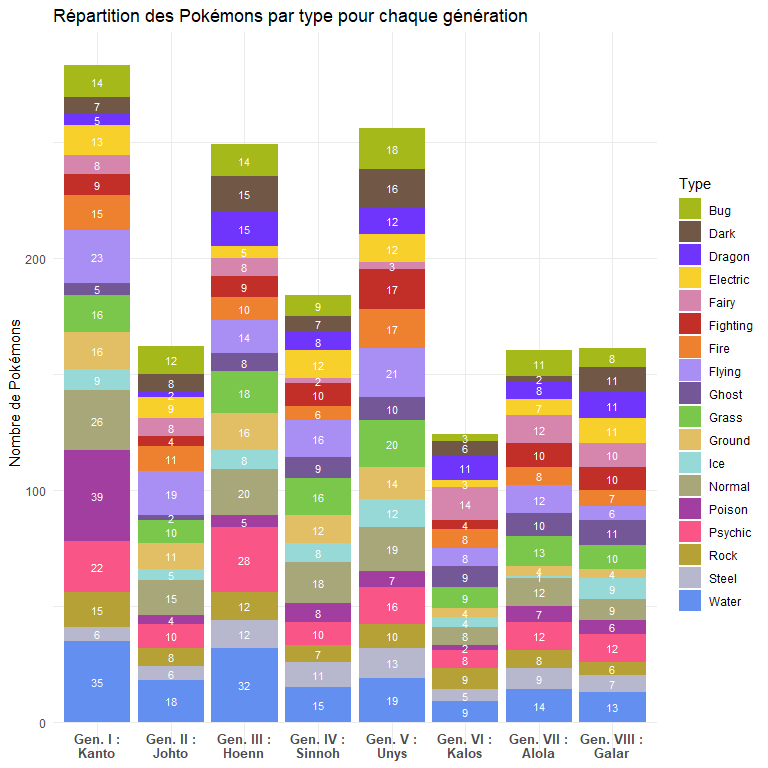

*Analyse :*

De manière générale, on voit que la répartition des types est assez proche d’une génération à l’autre. Cependant, on peut noter quelques exceptions intéressantes :

- Le nombre très élevé de Pokémons **Poison** dans la Première Génération
- La proportion de Pokémons de type **Sol** qui était relativement élevée dans les 5 premières générations alors qu’elle est quasiment nulle dans les 3 dernières générations

## 2. Etude des statistiques des Pokémons

### 2.1. Distribution des stats de base

*Objectif du graphique :* Ici, nous allons répondre à la question suivante : Comment les statistiques de l’ensemble des Pokémons sont-elles distribuées ?

*Présentation :* Nous allons ici étudier les 6 statistiques principales : **HP** (Points de vie), **Attaque**, **Défense**, **Attaque Spéciale**, **Défense Spéciale** et **Vitesse**.

*Visualisation :*

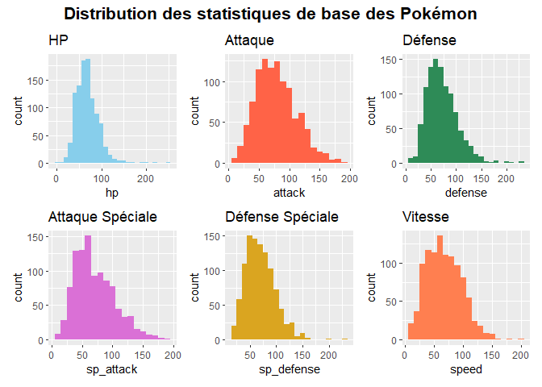

*Analyse :*

Globalement, la distribution de toutes les statistiques suit bien une Gaussienne, comme on pourrait s’y attendre.  
On note cependant une légère asymétrie, notamment pour l’**Attaque** et la **Défense**, où quelques valeurs sont bien plus élevées que la moyenne. Quelques Pokémons aux statistiques particulièrement élevées sortent donc du lot. On peut imaginer que ces Pokémons exceptionnels sont notamment les Pokémons **Légendaires**.

### 2.2. Comparaison des base stats des Pokémons légendaires et des Pokémons normaux

*Objectif du graphique :* Ici, nous allons répondre à la question suivante : Les Pokémons légdendaires sont-ils les plus forts ? Parmi tous les Pokémon existants, certains Pokémons sont considérés comme étant spéciaux : les Pokémon légendaires, iconiques à chaque jeu, accompagnés des Pokémon fabuleux. Introduits dans les jeux Pokémon X et Y, les méga-évolutions constituent également une catégorie à part.

*Présentation :* Afin de savoir si ces Pokémon sont réellement plus puissants que les autres, nous allons observer la répartition des totaux des statistiques de base (abrégé “base stats”) pour tous les Pokémons, en différenciant les légendaires des autres. Nous allons utiliser le dataset “The Complete Pokemon Dataset”. Les conditions des Pokémons légendaires, mythiques (“mythical” en anglais) et méga-évolutions sont dispersées dans 3 colonnes différentes que nous allons fusionner en une seule colonne “group”. Enfin, nous affichons l’histogramme du total de base stats, en différenciant les Pokémons spéciaux par la couleur.

*Visualisation :*

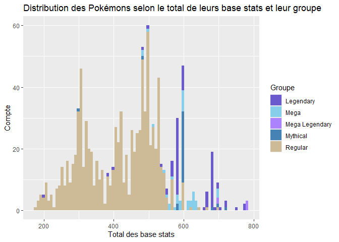

*Analyse :*

On peut observer que les Pokémons légendaires, fabuleux et méga-évolués possèdent bien un total de statistiques plus élevé que les Pokémons normaux. Ils constituent la quasi majorité de tous les Pokémons ayant 580 ou plus de base stats.

On observe également que la plupart des Pokémons spéciaux ont le même montant de base stats : 600, 580 ou 680.

De plus, les Pokémons les plus “puissants”, possédant le montant le plus élevé de base stats font partie d’un groupe rare : ils sont à la fois des méga-évolutions et des Pokémons légendaires (Méga Mewtwo X, Méga Mewtwo Y et Méga Rayquaza).

Il existe tout de même quelques cas de Pokémons spéciaux avec des statistiques moyennes voire faibles. On peut penser à Cosmog (200 de base stats), qui est un cas particulier parmi les Pokémons légendaires car il peut évoluer : sa dernière évolution, Solgaleo, possède lui 680 de base stats.

### 2.3. Statistiques des pokémons selon leur niveau d’évolution

*Objectif du graphique :*  
Ici, nous allons répondre à la question suivante : **Quelles sont les statistiques des pokémons selon leur niveau d’évolution ?** En effet, chaque niveau d’évolution peut avoir un impact significatif sur les statistiques d’un pokémon, telles que ses points de vie (HP), son attaque, sa défense, etc.

*Présentation :*  
Pour réaliser ce graphique, nous avons utilisé les données du dataset “Pokemon_data” et “pokemon-tcg-data-master 1999-2023.csv”. Nous avons filtré les Pokémon selon leur niveau d’évolution (1, 2 ou 3) dans le second dataset, et nous avons calculé la moyenne des statistiques pour chaque niveau d’évolution grâce au premier.

*Visualisation :*

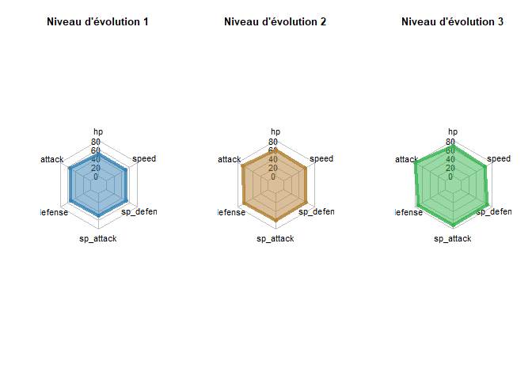

*Analyse :*  
Nous pouvons observer grâce à ces diagrammes radars que les statistiques des pokémons évoluent en fonction de leur niveau d’évolution. En effet, les pokémons de niveau d’évolution 1 ont des statistiques plus faibles que ceux de niveau d’évolution 2, qui eux-mêmes ont des statistiques plus faibles que ceux de niveau d’évolution 3. Cela est logique, car les pokémons de niveau d’évolution 3 sont généralement plus puissants que ceux de niveau d’évolution 2, qui eux-mêmes sont plus puissants que ceux de niveau d’évolution 1. Nous pouvons également observer que les statistiques des pokémons de niveau d’évolution 1 sont plus homogènes que celles des pokémons de niveau d’évolution 2 et 3. De plus, les statistiques n’évoluent pas toutes de la même manière. Par exemple : la vitesse évolue “peu” entre les niveaux d’évolution, à où l’attaque et la défense évoluent beaucoup plus.

### 2.4. Taille des Pokémon en fonction de leur poids, ainsi que de leur vitesse et du total de leurs statistiques de base

*Objectif du graphique :*

Ici, nous allons répondre à la question suivante : **Observe-t-on une relation entre le poids, la taille, la vitesse et le totale des statistiques de base d’un Pokémon ?**

Pour réaliser ce graphique, nous avons utilisé le jeu de données **The complete pokemon dataset**.

Pour des raisons de lisibilité du graphique, nous avons dû ignorer certaines valeurs extrêmes.

*Visualisation :*

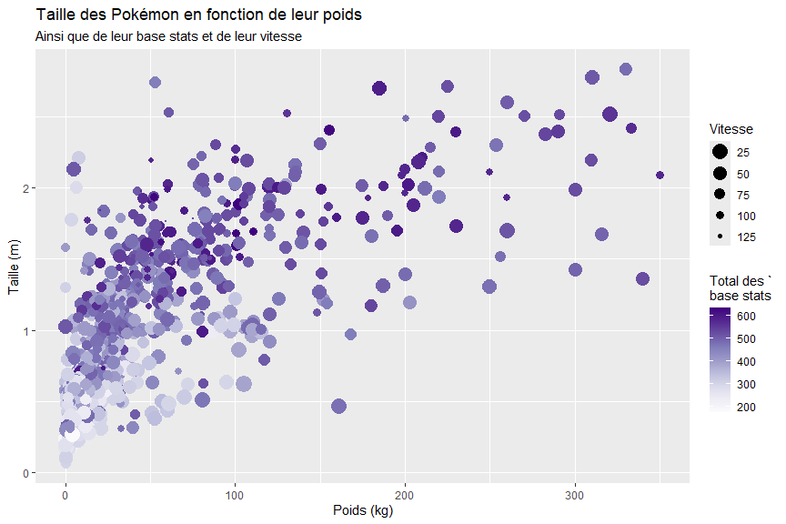

*Analyse :*

Nous n’observons pas de lien flagrant entre la vitesse et la taille / poids d’un Pokémon non plus. Contrairement à ce que l’on pourrait croire, la majorité des Pokémon légers (< 50kg) et petits (< 1m) sont lents. Les Pokémon rapides semblent plus être de taille moyenne ou grande (> 1m).

Quant au total des statistiques de base (base stats), on observe une tendance assez claire : les Pokémon petits (< 1m) ont des base stats plus faibles que les Pokémon de taille moyenne et grands.

La taille semble donc avoir plus de lien avec les statistiques des Pokémon que le poids.

## 3. Jeu de cartes Pokémon et tournois

### 3.1. Tournois Pokémons dans le monde

*Objectif du graphique :*  
Ici, nous allons répondre à deux questions :

- **Quels sont les pays qui organisent le plus de tournois Pokémon ?**
- **Quelles sont les nationalités qui ont le plus remporté de tournois ?**

*Présentation :*

Pour réaliser ce graphique, nous avons utilisé le jeu de données **Pokemon TCG - All Tournaments Decks**.  
L’objectif du graphique, au delà de répondre aux deux questions ci-dessus, est également de voir si l’on observe une corrélation entre ces deux facteurs

*Visualisation :*

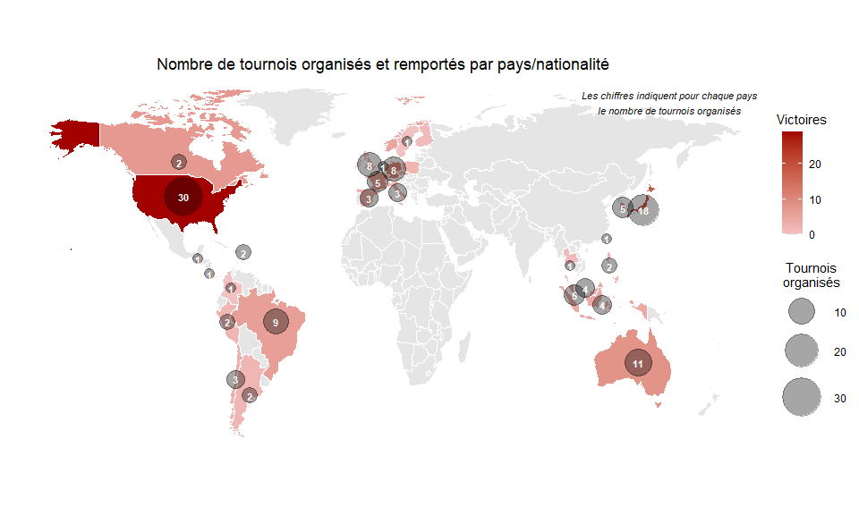

*Analyse :*

La corrélation entre le nombre de tournois organisés et le nombre de tournois remportés apparaît très clairement sur cette carte. Cela semble assez logique, ces deux données étant de bons indicateurs du développement de la culture Pokémon dans chaque pays.  
Cette culture semble être surtout développée dans 3 régions du monde :

- **L’Europe**
- **L’Amérique**
- **L’Océanie** et **l’Asie du Sud-Est**

Deux pays se démarquent encore des autres : le **Japon**, pays d’origine de la licence et les **Etats-Unis**

### 3.2. Cartes les plus utilisés en tournoi

*Objectif du graphique :*  
Ici, nous allons répondre à la question suivante : **Quelles sont les cartes les plus utilisées en tournoi officiel Pokémon ?**

*Présentation :*

Pour réaliser ce graphique, nous avons utilisé le jeu de données **Pokemon TCG - All Tournaments Decks**.  
Ce graphique prend en compte l’ensemble des decks de cartes jouées par chacun des joueurs à chacun des tournois officiels.

*Visualisation :*

[figure not shown]

*Analyse :*

Tout d’abord, on voit que beaucoup des Pokémons les plus utilisés possèdent un talent, c’est-à-dire une capacité spéciale. Cela n’est pas surprenant, puisque ces capacités constituent un avantage stratégique en duel. Cela explique que **Comfey** et **Archeops** soient les Pokémons les plus utilisés, puisqu’ils disposent d’un talent pouvant être utile avec n’importe quel deck, peu importe le type. On voit également qu’une proportion conséquente des cartes les plus utilisées sont des Pokémons de type **Normal**. Leur type leur permettant d’être utilisé en combinaison avec n’importe quel autre type, ce qui explique qu’ils soient joués dans beaucoup de decks différents.

### 3.3. Classement des joueurs dans les tournois de carte Pokémon en fonction du rang de leur deck en terme de prix dans le tournoi

*Objectif du graphique :*

Nous cherchons ici à répondre à la question suivante : **Le prix total d’un deck influence-t-il le classement final d’un joueur dans un tournoi de cartes Pokémon ? ?** Des tournois de cartes Pokémon sont organisés dans le monde entier. Dans chaque tournoi, les joueurs participent avec un deck qu’ils ont préalablement préparé. Il est intéressant d’analyser si le classement d’un deck en termes de prix peut avoir un impact sur le classement final du joueur dans le tournoi. Grâce à ce graphique, nous cherchons par exemple à savoir si un joueur ayant le deck le plus cher termine régulièrement dans le top 10 de la compétition. Nous avons créé un **boxplot** permettant de visualiser la médiane, les premier et troisième quartiles, ainsi que les valeurs aberrantes (outliers) pour chaque rang. Nous y avons également ajouté des courbes de tendance pour la médiane et la moyenne (hors outliers) en fonction du classement final. Un second **boxplot** a été réalisé pour présenter les statistiques de base concernant le prix des decks selon leur rang.

*Présentation :*

Pour réaliser ce graphique, nous avons utilisé les données du dataset **“tournaments.csv”**. Nous avons conservé uniquement les tournois comptant **au moins 10 participants**. Le prix du deck de chaque joueur a été calculé, puis nous avons déterminé le rang de chaque deck en termes de prix dans chaque tournoi. Ensuite, nous avons associé à chaque deck le classement final obtenu par le joueur. Enfin, nous avons pu créer un boxplot représentant le classement final du joueur en fonction du rang de son deck en termes de prix dans le tournoi.

*Visualisation :*

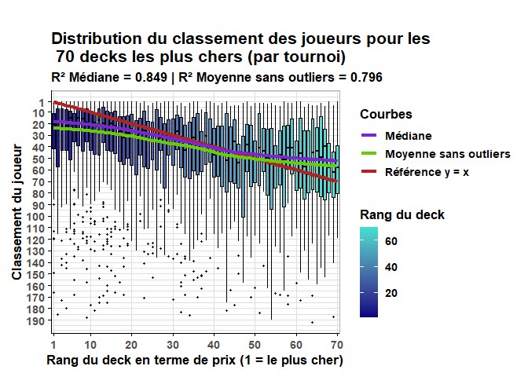

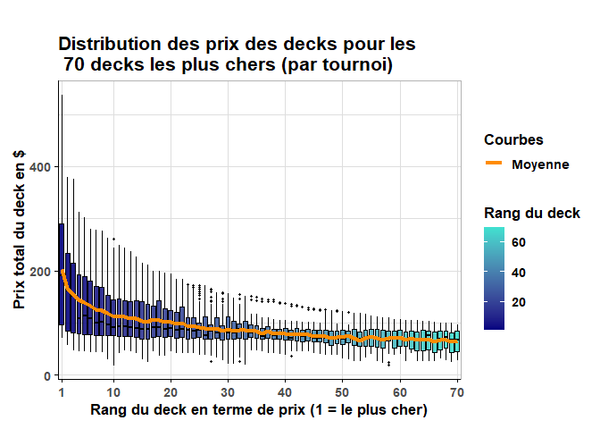

*Analyse :*

On observe globalement que les decks les plus chers des tournois **(top 20 en termes de prix)** sont associés aux meilleures performances. Par exemple, pour les decks les plus onéreux **(rang = 1)**, **50 %** des joueurs terminent dans le **top 20**, et **près de 25 %** atteignent le **top 10** du tournoi. À l’inverse, pour les decks classés au **rang 60**, **75 %** des joueurs terminent **en dehors du top 30.** Cependant, ce graphique ne permet pas d’identifier clairement une relation linéaire entre la performance en tournoi et le rang du deck en termes de prix.

**Le second graphique, qui présente le prix total des decks selon leur rang**, montre que le prix des decks décroît principalement pour **les 30 premiers rangs**. Au-delà, les prix restent relativement similaires. Cette faible variation peut expliquer l’absence de corrélation linéaire dans le premier graphique.

En conclusion, on peut avancer que les joueurs souhaitant viser les meilleures places doivent investir significativement plus que leurs adversaires. À l’inverse, ceux qui utilisent des decks au prix moyen peuvent espérer atteindre des positions intermédiaires, généralement **en dehors du top 40.**

*Shiny Dashboard :* Ces visualisations sont également disponibles dans un **Shiny Dashboard** interactif, permettant d’explorer les données de manière plus dynamique en filtrant le nombre de decks.

### 3.4. Comparaison entre prix de vente d’une carte et popularité d’un Pokémon, en fonction de leur génération

*Objectif du graphique :* Ici, nous allons répondre à deux questions :

- **La génération d’un Pokémon influe-t-elle sur le prix de ses cartes Pokémon ?**
- **Y a-t-il une corrélation entre popularité d’une génération et le prix de ses cartes ?**

Pour réaliser ce graphique, nous avons combiné plusieurs jeux de données :

- **Pokémon Trading Cards** : noms des cartes et leur prix
- **Sondage de popularité** : popularité des Pokémon
- **The complete pokemon dataset** : générations auxquelles appartiennent les Pokémons

Il faut noter que les cartes Pokémon qui ne concernent pas des Pokémon (cartes Dresseur, cartes Objet, etc.) ne sont pas prises en compte dans cette visualisation.

*Visualisation :*

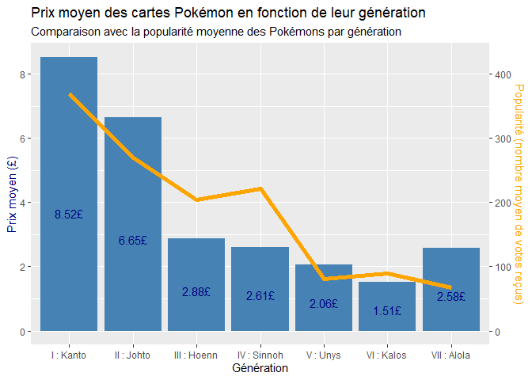

*Analyse :*

Tout d’abord, nous observons que la génération d’un Pokémon semble bien influer le prix des cartes. Les prix suivent une tendance décroissante de la première génération jusqu’à la sixième, puis remontent à la septième. Deux générations ressortent particulièrement : la première et la deuxième, qui ont des prix de vente moyens significativement plus élevés. Cela peut s’expliquer par le fait que les cartes les plus chères (Dracaufeu, Typhlosion, Raichu, Celebi, Mew, Nostenfer) appartiennent à ces deux générations.

Lorsque l’on compare avec la courbe de la popularité moyenne des Pokémons, on observe effectivement une corrélation. Les deux graphes suivent tous les deux une tendance décroissante, avec la popularité qui suit une tendance plus linéaire. Bien que le critère majeur du prix de vente d’une carte à collectionner soit sa rareté, il est possible que la popularité du Pokémon de la carte influe également. Une hypothèse probable est qu’il s’agit de la génération qui créé cette tendance : plus une carte est ancienne (et donc d’une génération ancienne) et plus elle est rare. De la même manière, un biais de nostalgie peut influer sur l’opinion des personnes et sur le choix de leur Pokémon préféré dans un sondage de popularité.

## 4. Jeux vidéos Pokémon

### 4.1. Visualisation de la popularité des jeux vidéos Pokémon à l’aide du nombre de ventes de 1996 à 2014

*Objectif du graphique :*

Ici, nous allons répondre aux questions suivantes : **À quel point les jeux vidéos Pokémon sont-ils populaires ? Les jeux récents sont-ils plus populaires que les anciens ?** Les jeux vidéos Pokémon existent depuis très longtemps et de nouveaux jeux ne cessent de sortir. À l’aide de ce graphique, le but est d’observer si les jeux vidéos Pokémon occupent une place importante sur le marché des jeux vidéos et de voir comment évolue cette place au cours du temps. Nous avons créé un barchart permettant de comparer chaque jeu vidéo Pokémon avec le jeu le plus vendu de la même année.

*Présentation :*

Pour réaliser ce graphique, nous avons utilisé les données du dataset **“vgsales.csv”**. Nous avons conservé uniquement les jeux Pokémon qui ont des ventes globales supérieures à 6 millions afin de conserver uniquement les jeux principaux de Pokémon et éliminer tous les spin-off. Nous avons ensuite comparer à l’aide d’un barchart le nombre de ventes des jeux Pokémon avec le jeu vidéo le plus vendu de la même année. On peut voir également la position du jeu Pokémon parmi les ventes globales de l’année.

*Visualisation :*

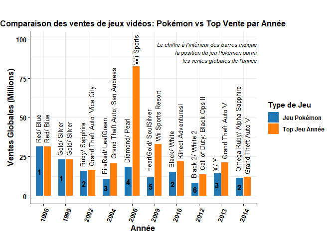

*Analyse :*

On peut observer que les jeux Pokémon récents se vendent globalement moins bien que les anciens. On peut remarquer cela car les 2 jeux Pokémon les plus vendus de l’histoire sont sortis en **1996 et 1999** avec respectivement **plus de 30 et 20 millions** de ventes, tandis que les plus récents peine à atteindre les **20 millions** de ventes.

Cependant à l’aide des rangs des jeux Pokémon parmi les ventes globales de chaque année, on peut voir qu’à chaque sortie d’un nouveau jeu Pokémon, ce dernier figure presque toujours parmi le **TOP 5** des ventes de l’année. Récemment, il est rare de voir des jeux Pokémon en première position comme on avait pu le voir en **1996 et 1999**. Mais on peut conclure que les jeux Pokémon occupe toujours une place très importante sur le marché du jeu vidéo. On peut expliquer cette baisse des ventes par le fait qu’il y’a de plus en plus de concurrence et un manque de nouveauté dans le contenu.

### 4.2 Visualisation de la répartition régionale des ventes des jeux Pokémon de 1996 à 2014

*Objectif du graphique :*

Nous cherchons ici à répondre aux questions suivantes : **Comment les ventes des jeux Pokémon se répartissent au sein des régions ? Est-ce que cette répartition est différente selon le jeu et l’année ?** Les jeux vidéos Pokémon ont été développés par des studios Japonais, et pourtant le succès des jeux est visible dans le monde eniter. À l’aide de ce graphique, le but est de comparer les proportions des ventes entre chaque région pour comprendre la popularité du jeu dans la région. Nous avons créé un barchart permettant de comparer les proportions des ventes entre chaque région pour chaque jeu.

*Présentation :*

Pour réaliser ce graphique, nous avons utilisé les données du dataset **“vgsales.csv”**. Nous avons conservé uniquement les jeux Pokémon qui ont des ventes globales supérieures à 6 millions afin de conserver uniquement les jeux principaux de Pokémon et éliminer tous les spin-off.

*Visualisation :*

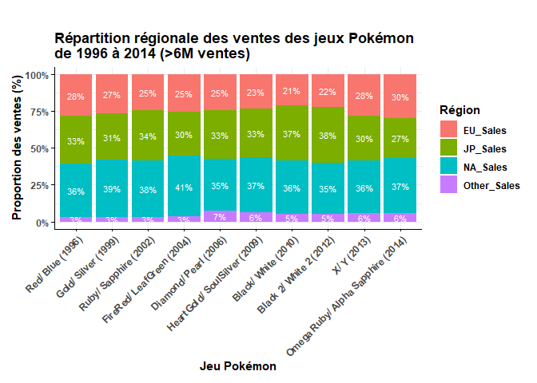

*Analyse :*

On observe tout de même certaines exceptions. Pour les jeux **Pokémon Noir & Blanc**, **l’Europe** affiche ses pires score avec **21 et 22 %**, au profit du **Japon**, qui atteint ses meilleurs scores avec **37 et 38 %**.

# III. Conclusion

Au cours de ce projet, nous avons exploré divers aspects de l’univers Pokémon à travers des visualisations de données. Nous avons analysé les performances des decks de cartes Pokémon dans les tournois, la popularité des jeux vidéo Pokémon et la répartition régionale des ventes. Ces visualisations nous ont permis de mieux comprendre les tendances et les dynamiques au sein de la franchise Pokémon, ainsi que l’impact de la popularité des cartes et des jeux sur les performances en tournoi et les ventes globales. Nous avons constaté que les decks les plus chers sont souvent associés aux meilleures performances en tournoi, tandis que les jeux vidéo Pokémon continuent de dominer le marché malgré une légère baisse des ventes récentes. Enfin, la répartition régionale des ventes montre que l’Amérique du Nord et le Japon sont les principaux marchés pour les jeux Pokémon, avec une part significative des ventes en Europe. Ces analyses soulignent l’importance de la franchise Pokémon dans le monde du divertissement et son influence durable sur les joueurs et les fans à travers le monde.

Au terme de cette analyse, il convient d’insister sur l’importance de la visualisation des données dans la compréhension de jeux de données complexes. Les graphiques et les visualisations interactives permettent de révéler des tendances, des corrélations et des insights qui pourraient passer inaperçus dans des tableaux de données brutes. En rendant les données accessibles et compréhensibles, nous pouvons mieux apprécier la richesse et la diversité de l’univers Pokémon, tout en fournissant une base solide pour des analyses futures.